# Sound speed profile from impulse response

**NoteReference**

This tutorial is adapted from `Example D` presented in:

- Mandar Chitre, “[Differentiable Ocean Acoustic Propagation Modeling](https://arl.nus.edu.sg/wp-content/uploads/2023/04/Chitre_Differentiable-Ocean-Acoustic-Propagation-Modeling.pdf),” in OCEANS 2023 IEEE/MTS – Limerick, 5-8 June 2023.

## Key idea

Since the sound speed profile is an unknown function of depth, we model it using a small 3-layer neural network. We initialize the parameters by training the neural network on the known/estimated sound speed profile from the previous week. We use the neural network to provide sound speed estimates to `RaySolver`, thus effectively creating a model that combines a numerical physics-based differential equation solver with a data-driven neural network. The hybrid model returns a vector of predicted delays of the first few multipath arrivals in the impulse response. We minimize a loss function that measures the difference between the predictions and measurements using gradient descent and automatic differentiation. This essentially trains the neural network to approximate the sound speed profile via a loss function that utilizes the propagation model. At the end of each week’s training, we get a revised estimate of the sound speed profile.

## Dataset

To illustrate this idea, let us generate a synthetic dataset:

```julia
using UnderwaterAcoustics
using AcousticRayTracers

# define Munk sound speed profile
struct MunkSSP <: UnderwaterAcoustics.DepthDependent end

function (ssp::MunkSSP)(pos)
  ϵ = 0.00737
  z̃ = 2.0 * (-pos.z - 1300.0) / 1300.0
  1500.0 * (1.0 + ϵ * (z̃ - 1 + exp(-z̃)))
end

# simulate acoustic propagation using RaySolver to generate impulse response
function model(h, r, d1, d2, c, n)
  env = UnderwaterEnvironment(bathymetry=h, seabed=Rock, soundspeed=c)
  pm = RaySolver(env)
  tx = AcousticSource(0.0, -d1, 1000.0)
  rx = AcousticReceiver(r, -d2)
  arr = arrivals(pm, tx, rx)
  t = getfield.(arr, :t)        # get a.t for each arrival a in arr
  (t[2:n] .- t[1]) .* 1000      # relative time in milliseconds
end

# estimated sound speed profile from previous week
prev_depths = [0, 500.0, 1000.0, 2000.0, 3000.0, 4000.0, 5000.0]
prev_soundspeeds = [1518.6, 1494.5, 1490.6, 1505.8, 1530.3, 1556.7, 1583.6]

# generate data with first 6 multipath delays
data = model(5000.0, 10000.0, 1000.0, 1800.0, MunkSSP(), 7)
```

```
6-element Vector{Float64}:
  178.43092536362093
 1406.7111303175395
 2245.7945445383557
 3008.6910493939545
 4014.4235390005783
 6395.563124452437
```

[figure not shown]

The previous week’s sound speed profile is shown in the plot above as solid circles, whereas the true sound speed profile is shown as a blue line.

## Neural network based propagation model

We don’t know the sound speed profile, so we will use a small 3-layer neural network to model it:

```julia
using SimpleChains
using StaticArrays
using Random: MersenneTwister

# neural network based sound speed profile data type
struct NeuralSSP{T1,T2} <: UnderwaterAcoustics.DepthDependent
  model::T1                 # neural network structure
  ps::T2                    # neural network parameters
  max_depth::Float64        # used for scaling the input
  min_soundspeed::Float64   # used for scaling the output
  max_soundspeed::Float64   # used for scaling the output
end

# scale input, pass through the neural network, and scale output
function (ssp::NeuralSSP)(pos)
  z̄ = -pos.z / ssp.max_depth
  c̄ = only(ssp.model(SA[z̄], ssp.ps))
  (c̄ + 1) / 2 * (ssp.max_soundspeed - ssp.min_soundspeed) + ssp.min_soundspeed
end

# define the neural network
ssp = let mlp = SimpleChain(
    static(1),
    TurboDense(tanh, 3),
    TurboDense(tanh, 3),
    TurboDense(tanh, 1)
  )
  ps = SimpleChains.init_params(mlp; rng=MersenneTwister(0))
  NeuralSSP(mlp, ps, 5000.0, 1450.0, 1600.0)
end
```

We initialize the neural network parameters by training the neural network on the known/estimated sound speed profile from the previous week:

```julia
c̄ = @. (prev_soundspeeds - ssp.min_soundspeed) / (ssp.max_soundspeed - ssp.min_soundspeed) * 2 - 1
z̄ = @. prev_depths / ssp.max_depth
G = SimpleChains.alloc_threaded_grad(ssp.model)
L = SimpleChains.add_loss(ssp.model, SquaredLoss(transpose(c̄)))
SimpleChains.train!(G, ssp.ps, L, transpose(collect(z̄)), SimpleChains.ADAM(0.1), 10000)
```

We plot the model output against the training data to check that it fits well:

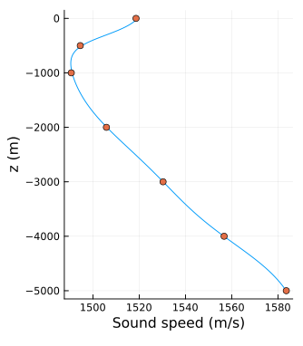

```julia
plot(ssp, -5000, 0; xlabel="Sound speed (m/s)", size=(350, 400))
scatter!(prev_soundspeeds, -prev_depths)
```

Now we define a loss function that computes the difference between the predictions of `RaySolver` using the sound speed given by the `NeuralSSP`, and the measured impulse response:

```julia
# compute loss using predictions of RaySolver using the NeuralSSP
function loss(ps)
  ssp1 = NeuralSSP(ssp.model, ps, 5000.0, 1450.0, 1600.0)
  pred = model(5000.0, 10000.0, 1000.0, 1800.0, ssp1, length(data)+1)
  sum(abs2, pred - data)
end
```

and perform gradient descent to minimize the loss function:

```julia
import ForwardDiff

η = 1e-6            # learning rate
ps = copy(ssp.ps)   # start with the previous week’s parameters

# this will take a few minutes to run...
for i ∈ 1:20
  g = ForwardDiff.gradient(loss, ps)
  ps .-= η .* g     # gradient descent
end
```

We plot the trained neural sound speed profile against the ground truth:

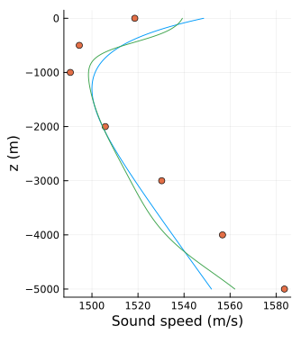

```julia
let ssp = NeuralSSP(ssp.model, ps, 5000.0, 1450.0, 1600.0)
  plot(MunkSSP(), -5000, 0; xlabel="Sound speed (m/s)", size=(350, 400))
  scatter!(prev_soundspeeds, -prev_depths)
  plot!(ssp, -5000, 0)
end
```

and see that it indeed fits quite well!